# The Effect of Quality of Sleep and Gender on Sleep Disorders

# 4 LASSO Linear regularized regression

To model the continous outcome Quality of Sleep variable, LASSO regression using 10-fold cross validation was applied to determine the optimal regularization parameter(lamba.min). The dataset was split into training (80%) and test (20%) sets, with model matrices generated to accomodate dummy variables.

```r
sleep_model <- sleep %>%
  filter(!is.na(Quality.of.Sleep)) %>%
  drop_na()

set.seed(123)

train_idx <- caret::createDataPartition(sleep_model$Quality.of.Sleep, p = 0.8, list = FALSE)
train_data <- sleep_model[train_idx, ]
test_data  <- sleep_model[-train_idx, ]

formula <- Quality.of.Sleep ~ .
X_train <- model.matrix(formula, data = train_data)[, -1]  # remove intercept
y_train <- train_data$Quality.of.Sleep
train_cols <- colnames(X_train)
X_test <- model.matrix(formula, data = test_data)[, -1]
y_test  <- test_data$Quality.of.Sleep

# Ensure same column structure
missing_cols <- setdiff(train_cols, colnames(X_test))

# Add any missing columns to X_test as zeros
for (col in missing_cols) {
  X_test <- cbind(X_test, setNames(data.frame(0), col))
}

# Reorder columns to match training set exactly
X_test <- X_test[, train_cols]

# Add missing columns as zeros
for (col in missing_cols) {
  X_test[[col]] <- 0
}

# Reorder to match training set
X_test <- X_test[, train_cols]

# Convert to numeric matrix
X_test <- as.matrix(X_test)
mode(X_test) <- "numeric"

y_test <- test_data$Quality.of.Sleep
cv_lasso <- cv.glmnet(X_train, y_train, alpha=1)
predicted_test <- predict(cv_lasso, newx = X_test, s = "lambda.min")

rmse_test <- sqrt(mean((y_test - predicted_test)^2))
rsq_test <- 1 - sum((y_test - predicted_test)^2) / sum((y_test - mean(y_test))^2)

cat("Test RMSE:", round(rmse_test, 2), "\n")
```

```
Test RMSE: 0.16
```

```r
cat("Test R-squared:", round(rsq_test, 3), "\n")
```

```
Test R-squared: 0.981
```

The test RMSE is 0.16 which indicates that the model predicts Quality of sleep with an average error of +/- 0.16 units on test data, which is fairly accurate. The test R-squared is 0.98. This indicates that the model explains 98.1% of the variance in sleep quality on unseen data or test data. These results confirm that the model is not overfitting the data and it generalizes well from training to test data.

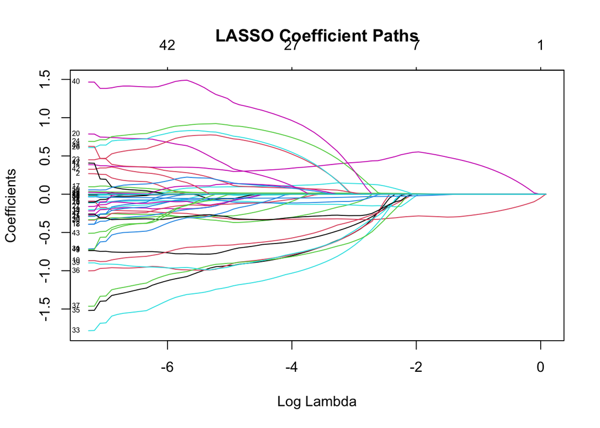

```r
# Plot for LASSO coefficient paths
plot(cv_lasso$glmnet.fit, xvar = "lambda", label = TRUE)
title("LASSO Coefficient Paths")
```

This plot shows the regression coefficients for each predictor in the model change as the regularization penalty (log lambda) increases.It shows that most predictors have non-zero coefficients. many coefficients shrink toward zero. The horizontal axis, the penalty increases towards the right. The predictors with higher magnitude coefficients are more influential in predicting Quality of sleep.